# Fragmentation Spectra

Pietro Franceschi | pietro.franceschi@fmach.it

```r
library(MsExperiment)
library(xcms)
library(tidyverse)
library(plotly)
```

## Introduction

The objective of this demo is to show how `xcms` can be used to read the results of fragmentation experiments and how to use them to perform annotation.

Annotation is the process of going back from features to compounds and it can be considered one of the challenges (maybe the biggest) in metabolomics. In the real world, annotation is an effort which integrates many different expertises, ranging from chemistry to informatics and chemoinformatics …

Annotation in MS is particularly challenging because a mass spectrometer is basically a tool able to measure only mass to charge ratios … can you imagine how difficult it would be to distinguish people only on the basis of their weight?

Fragmentation experiments, often called MS/MS, are an essential tool for this task. They can be used either to deduce information on the chemical characteristics of unknown compounds, or to confirm the annotation when authentic chemical standards are available.

In this second case, the typical workflow is to inject the standards with the same analytical pipeline used for the samples, and then use m/z, rt and MS/MS to confirm the presence of a given compound in the samples.

The importance of reliable and efficient databases of chemical standards cannot be overlooked, and the community is putting a lot of effort on that in terms of data organization, standardization and development of specific software libraries.

## Reading MS/MS

Let’s suppose that we have a library of standards in our lab, and that we injected them with the same chromatography used for the wines. Among other compounds, our library contains three procyanidins: B1, B2 and B3. They are rather large polyphenols, widely present in many matrices of plant origin.

Our analytical facility told us that they were analysed (together with other compounds) in three injections:

- B3: x015_mix02_2_NEG_DDA.mzML
- B2: x016_mix03_2_NEG_DDA.mzML
- B1: x017_mix04_2_NEG_DDA.mzML

We also know that in negative ion mode all three molecules mainly yield the [M-H]<sup>-</sup> ion (m/z 577.1352).

Our task is to confirm (or not) the presence of the three of them in the wine samples.

```r
std_files <- list.files("../data/wines/", pattern = "mix", full.names = TRUE)

standards <- tibble(compound = c("B3", "B2", "B1"),
                    file = basename(std_files))
standards
```

```
## # A tibble: 3 × 2
##   compound file
##   <chr>    <chr>
## 1 B3       x015_mix02_2_NEG_DDA.mzML
## 2 B2       x016_mix03_2_NEG_DDA.mzML
## 3 B1       x017_mix04_2_NEG_DDA.mzML
```

```r
std_colors <- c(B3 = "steelblue", B2 = "orange", B1 = "#8B3A3A")
```

## Identify the retention time

First of all we have to identify the retention time of each standard. This could be done manually or automatically. The manual way is to look for peaks in the extracted ion trace of the m/z 577.1352 ion and identify the position of the peak.

The automatic way is to do peak picking … but this will be part of your assignment ;-)

```r
std_raw <- readMsExperiment(spectraFiles = std_files) |>
  filterMsLevel(1)   ## only full scan
```

Since we know what we are looking for, let’s get the extracted ion traces and put them in a tibble

```r
proc_chrom <- chromatogram(std_raw, mz = 577.1352 + 0.02 * c(-1, 1))

chrom_df <- map(seq_along(std_files), \(k) {
  tibble(compound = standards$compound[k],
         rt = rtime(proc_chrom[1, k]),
         intensity = intensity(proc_chrom[1, k]))
}) |>
  list_rbind()
```

The plot is interactive, so we can zoom in to spot the right retention time

```r
ggplotly(
  chrom_df |>
    ggplot(aes(x = rt, y = intensity, col = compound)) +
    geom_line() +
    scale_color_manual(values = std_colors) +
    labs(x = "retention time (s)") +
    theme_light()
)
```

[interactive chart not shown]

Each injection shows a large peak between 200 and 300 s. In the B3 injection there is also a peak at the beginning of the chromatogram: the extracted ion trace is not specific, and other compounds of the mix can give a signal at the same m/z.

The tentative position of the peaks is the top of the trace between 200 and 300 s

```r
apex <- chrom_df |>
  filter(between(rt, 200, 300)) |>
  slice_max(intensity, n = 1, by = compound)

apex
```

```
## # A tibble: 3 × 3
##   compound    rt intensity
##   <chr>    <dbl>     <dbl>
## 1 B3        242.   331704.
## 2 B2        267.   465110.
## 3 B1        234.   898726.
```

so B3 elutes at 242 s, B2 at 267 s and B1 at 234 s.

Let’s look at the full scan spectrum at the top of the B1 peak (the third injection):

```r
b1_full_scan <- spectra(std_raw[3]) |>
  filterRt(apex$rt[apex$compound == "B1"] + 0.01 * c(-1, 1))

ggplotly(
  tibble(mz = mz(b1_full_scan)[[1]], intensity = intensity(b1_full_scan)[[1]]) |>
    ggplot(aes(x = mz, xend = mz, y = 0, yend = intensity)) +
    geom_segment() +
    labs(x = "m/z") +
    theme_light()
)
```

[interactive chart not shown]

The full scan spectrum contains the [M-H]<sup>-</sup> ion of B1, its isotopes and the ions of everything else eluting at the same time … but it does not tell us anything about the structure of the molecule. To get that we have to look at the MS2 (fragmentation) spectra:

```r
std_MS_MS <- readMsExperiment(spectraFiles = std_files) |>
  filterMsLevel(2)   ## only fragmentation
```

The question to be addressed now is: do we have fragmentation spectra of the ion at m/z 577?

The list of precursor ions can be directly accessed with

```r
std_MS_MS |>
  spectra() |>
  precursorMz() |>
  head(10)
```

```
##  [1] 330.8706 330.8705 194.9464 194.9465 330.8705 330.8703 330.8704 330.8705
##  [9] 330.8704 194.9464
```

But two handy methods can be used to filter the spectra on the precursor m/z and on the retention time

```r
focus_MS_MS <- std_MS_MS |>
  spectra() |>
  filterPrecursorMzValues(577.1352, ppm = 10) |>
  filterRt(rt = c(224, 280))

focus_MS_MS
```

```
## MSn data (Spectra) with 4 spectra in a MsBackendMzR backend:
##     msLevel     rtime scanIndex
##   <integer> <numeric> <integer>
## 1         2   243.048       530
## 2         2   269.175       578
## 3         2   232.841       506
## 4         2   237.791       515
##  ... 34 more variables/columns.
##
## file(s):
## x015_mix02_2_NEG_DDA.mzML
## x016_mix03_2_NEG_DDA.mzML
## x017_mix04_2_NEG_DDA.mzML
## Processing:
##  Filter: select MS level(s) 2 [Thu Nov 19 16:32:16 2026]
##  Filter: select spectra with precursor m/z matching 577.1352 [Thu Nov 19 16:32:16 2026]
##  Filter: select retention time [224..280] on MS level(s)  [Thu Nov 19 16:32:16 2026]
```

Let’s see where they come from

```r
focus_info <- tibble(file = basename(dataOrigin(focus_MS_MS)),
                     rt = rtime(focus_MS_MS),
                     precursor_mz = precursorMz(focus_MS_MS)) |>
  left_join(standards, by = "file")

focus_info
```

```
## # A tibble: 4 × 4
##   file                         rt precursor_mz compound
##   <chr>                     <dbl>        <dbl> <chr>
## 1 x015_mix02_2_NEG_DDA.mzML  243.         577. B3
## 2 x016_mix03_2_NEG_DDA.mzML  269.         577. B2
## 3 x017_mix04_2_NEG_DDA.mzML  233.         577. B1
## 4 x017_mix04_2_NEG_DDA.mzML  238.         577. B1
```

We have 4 spectra compatible with our rules: one for B3, one for B2 and 2 for B1. This is not unreasonable: the B1 peak is the largest one, and in DDA the ion at m/z 577 was selected for fragmentation in two different cycles. They are two spectra of the same compound.

Let’s now make a nice plot of the MS/MS spectra, with the intensities relative to the most intense fragment:

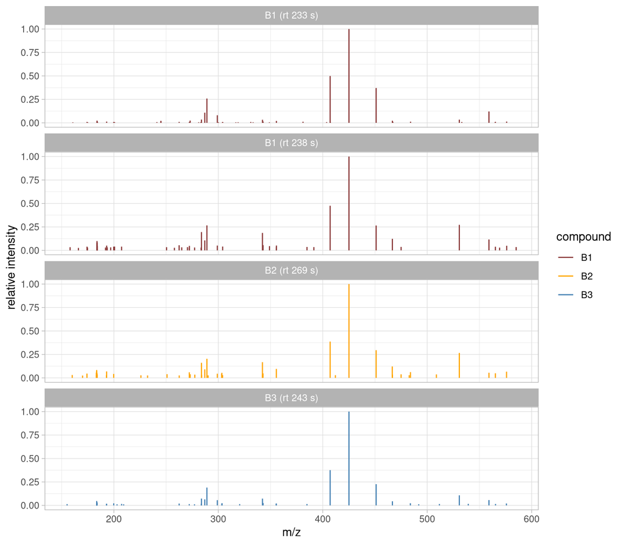

```r
msms_df <- focus_info |>
  mutate(spectrum = sprintf("%s (rt %.0f s)", compound, rt),
         peaks = map(as.list(peaksData(focus_MS_MS)), as_tibble)) |>
  unnest(peaks) |>
  mutate(rel_intensity = intensity / max(intensity), .by = spectrum)

msms_df |>
  ggplot(aes(x = mz, xend = mz, y = 0, yend = rel_intensity, col = compound)) +
  geom_segment() +
  facet_wrap(~spectrum, ncol = 1) +
  scale_color_manual(values = std_colors) +
  labs(x = "m/z", y = "relative intensity") +
  theme_light()
```

So, as expected, the three procyanidins give substantially the same fragmentation spectrum: they are isomers, with the same atoms and very similar structures. What makes the difference here is the retention time!

## DIY

Try to check if these compounds are visible in our wine samples. Hints:

1. check the extracted ion trace of the m/z 577 ion
2. check if this ion was fragmented

## A possible solution

We read the wine samples (QCs and blanks are not needed)

```r
wine_files <- list.files("../data/wines/", pattern = "_(red|wht)_", full.names = TRUE)

wines <- readMsExperiment(spectraFiles = wine_files)
```

### 1. The extracted ion trace

```r
wine_chrom <- chromatogram(wines |> filterMsLevel(1),
                           mz = 577.1352 + 0.02 * c(-1, 1),
                           rt = c(200, 300))

wine_chrom_df <- map(seq_along(wine_files), \(k) {
  tibble(file = basename(wine_files[k]),
         rt = rtime(wine_chrom[1, k]),
         intensity = intensity(wine_chrom[1, k]))
}) |>
  list_rbind() |>
  mutate(color = if_else(str_detect(file, "_red_"), "red", "white"))
```

We plot the traces of all the wines, with the retention times of the three standards as dashed lines:

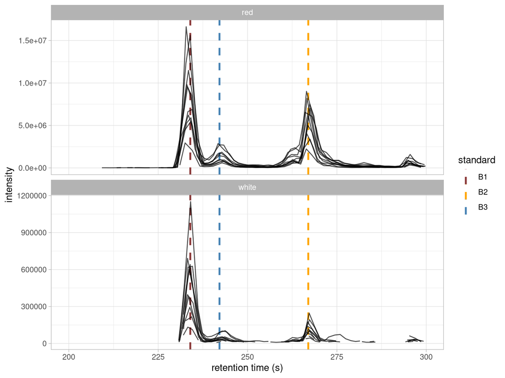

```r
wine_chrom_df |>
  ggplot(aes(x = rt, y = intensity, group = file)) +
  geom_vline(data = apex, aes(xintercept = rt, col = compound), lty = 2, linewidth = 1) +
  geom_line(alpha = 0.7) +
  facet_wrap(~color, ncol = 1, scales = "free_y") +
  scale_color_manual(values = std_colors, name = "standard") +
  labs(x = "retention time (s)") +
  theme_light()
```

```r
wine_apex <- wine_chrom_df |>
  slice_max(intensity, n = 1, by = c(file, color), with_ties = FALSE)

wine_apex |>
  summarise(n_wines = n(),
            median_rt = median(rt),
            median_intensity = median(intensity),
            .by = color)
```

```
## # A tibble: 2 × 4
##   color n_wines median_rt median_intensity
##   <chr>   <int>     <dbl>            <dbl>
## 1 red        10      233.         8285015.
## 2 white      10      234.          499991.
```

- The main peak of all the wines elutes at about 234 s, the retention time of B1
- It is much more intense in red wines (17 times, comparing the medians): procyanidins come from the skins and the seeds of the grapes, and red wines are macerated with them
- A second peak elutes at the retention time of B2, again much higher in red wines, and a small one at the retention time of B3 is visible in the red wines

### 2. Was the ion fragmented?

We look for MS/MS spectra with precursor m/z 577.1352 in the same retention time window, and we assign each of them to the standard with the closest retention time:

```r
wine_MS_MS <- wines |>
  filterMsLevel(2) |>
  spectra() |>
  filterPrecursorMzValues(577.1352, ppm = 10) |>
  filterRt(rt = c(200, 300))

wine_msms_info <- tibble(file = basename(dataOrigin(wine_MS_MS)),
                         rt = rtime(wine_MS_MS),
                         precursor_intensity = precursorIntensity(wine_MS_MS)) |>
  mutate(color = if_else(str_detect(file, "_red_"), "red", "white"),
         closest_standard = map_chr(rt, \(r) apex$compound[which.min(abs(r - apex$rt))]),
         delta_rt = map2_dbl(rt, closest_standard, \(r, cpd) r - apex$rt[apex$compound == cpd]))

wine_msms_info |>
  count(closest_standard, color)
```

```
## # A tibble: 4 × 3
##   closest_standard color     n
##   <chr>            <chr> <int>
## 1 B1               red      17
## 2 B1               white     3
## 3 B2               red      10
## 4 B3               red       2
```

32 MS/MS spectra of the m/z 577 ion were recorded in 13 wines. Let’s compare the most intense one close to the B1 standard with the spectrum of the standard in a mirror plot:

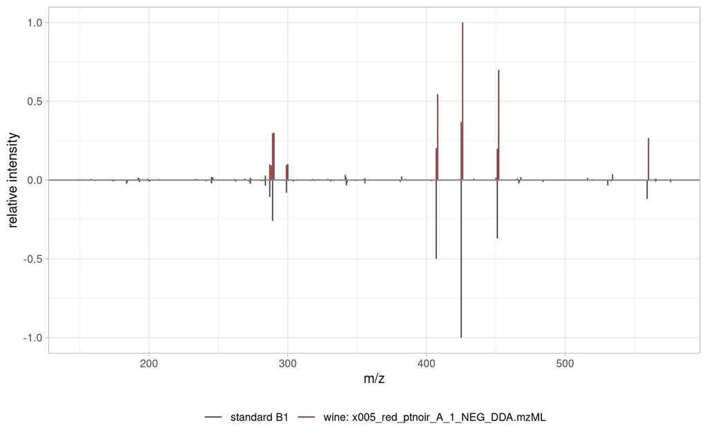

```r
best_wine <- wine_msms_info |>
  mutate(id = row_number()) |>
  filter(closest_standard == "B1") |>
  slice_max(precursor_intensity, n = 1)

mirror_df <- bind_rows(
  as_tibble(peaksData(wine_MS_MS)[[best_wine$id]]) |>
    mutate(spectrum = paste("wine:", best_wine$file)),
  as_tibble(peaksData(focus_MS_MS)[[which(focus_info$compound == "B1")[1]]]) |>
    mutate(spectrum = "standard B1")
) |>
  mutate(rel_intensity = intensity / max(intensity), .by = spectrum) |>
  mutate(rel_intensity = if_else(spectrum == "standard B1", -rel_intensity, rel_intensity))

mirror_df |>
  ggplot(aes(x = mz, xend = mz, y = 0, yend = rel_intensity, col = spectrum)) +
  geom_segment() +
  geom_hline(yintercept = 0, col = "gray50") +
  scale_color_manual(values = c("gray30", "#8B3A3A"), name = NULL) +
  labs(x = "m/z", y = "relative intensity") +
  theme_light() +
  theme(legend.position = "bottom")
```

The same m/z, the same retention time (233.7 s in the wine, 234 s for the standard) and a similar fragmentation pattern: B1 is in our wines!